# Mental illnesses

Martin Sándor (F145XS)

2024-11-26

# Mentális betegségek elemzése

Az adatokat az [internetről szedtem le](https://www.kaggle.com/code/imtkaggleteam/mental-health-eda-prediction), fogalmam sincs, hogy valósak-e. Az oszlopokat átneveztem a könnyebb hivatkozás érdekében

## Az adatok megismerése

```r
illnesses <- read.csv('mental_illnesses.csv')
head(illnesses)
```

```
##        Entity Code Year Schizophrenia Depressive_disorders Anxiety_disorders
## 1 Afghanistan  AFG 1990     0.2232058             4.996118          4.713314
## 2 Afghanistan  AFG 1991     0.2224538             4.989290          4.702100
## 3 Afghanistan  AFG 1992     0.2217512             4.981346          4.683743
## 4 Afghanistan  AFG 1993     0.2209872             4.976958          4.673549
## 5 Afghanistan  AFG 1994     0.2201830             4.977782          4.670810
## 6 Afghanistan  AFG 1995     0.2194088             4.978228          4.668100
##   Bipolar_disorders Eating_disorders
## 1         0.7030231        0.1277000
## 2         0.7020688        0.1232559
## 3         0.7007920        0.1188441
## 4         0.7000869        0.1150889
## 5         0.6998978        0.1118147
## 6         0.6997684        0.1085070
```

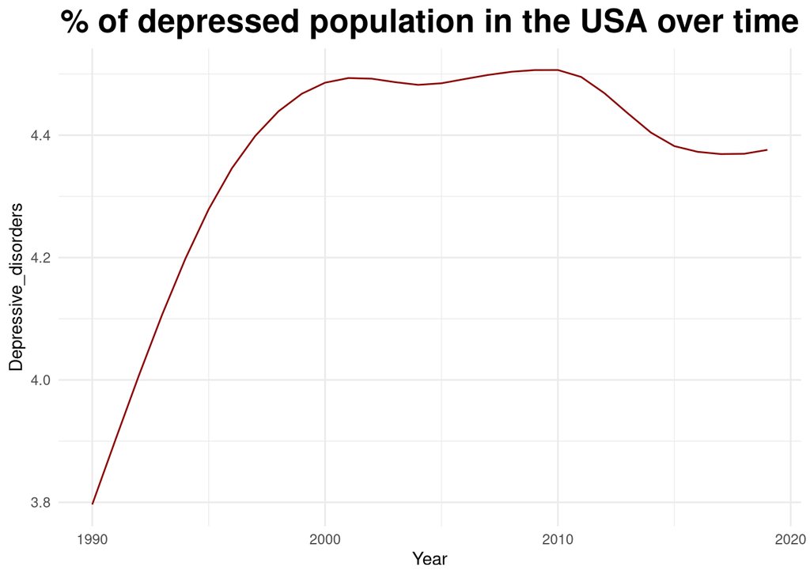

```r
usa_illnesses <- illnesses[illnesses["Code"] == "USA",]

#All disorders are represented as a % of the population
library(ggplot2)
ggplot(usa_illnesses, aes(x=Year, y=Depressive_disorders)) + geom_line(color="red4") + theme_minimal() + labs(title= "% of depressed population in the USA over time") + theme(plot.title = element_text(hjust=0.5, size=20, face="bold"))
```

Országonként nagy eltérések lehetnek az adatokban

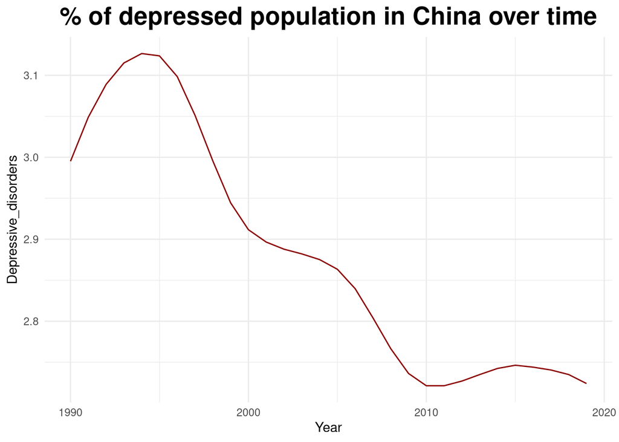

```r
china_illnesses <- illnesses[illnesses["Code"] == "CHN",]
china_disorders <- china_illnesses[,4:ncol(china_illnesses)]

ggplot(china_illnesses, aes(x=Year, y=Depressive_disorders)) + geom_line(color="red4") + theme_minimal() + labs(title= "% of depressed population in China over time") + theme(plot.title = element_text(hjust=0.5, size=20, face="bold"))
```

```r
usa_disorders <- usa_illnesses[c("Schizophrenia", "Depressive_disorders", "Anxiety_disorders", "Bipolar_disorders", "Eating_disorders")]
head(usa_disorders)
```

```
##      Schizophrenia Depressive_disorders Anxiety_disorders Bipolar_disorders
## 6061     0.4358578             3.796487          5.241197         0.6061742
## 6062     0.4393758             3.902555          5.241587         0.6059420
## 6063     0.4425686             4.006986          5.247779         0.6057076
## 6064     0.4452558             4.106528          5.259005         0.6054803
## 6065     0.4472567             4.198135          5.274653         0.6052701
## 6066     0.4483917             4.278906          5.293726         0.6050555
##      Eating_disorders
## 6061        0.4040804
## 6062        0.4185396
## 6063        0.4315340
## 6064        0.4419621
## 6065        0.4491788
## 6066        0.4522967
```

```r
cor(usa_disorders)
```

```
##                      Schizophrenia Depressive_disorders Anxiety_disorders
## Schizophrenia           1.00000000            0.5882931        0.56515541
## Depressive_disorders    0.58829305            1.0000000        0.58974808
## Anxiety_disorders       0.56515541            0.5897481        1.00000000
## Bipolar_disorders      -0.01970275           -0.6330952        0.06940822
## Eating_disorders        0.86225109            0.6442370        0.60833273
##                      Bipolar_disorders Eating_disorders
## Schizophrenia              -0.01970275       0.86225109
## Depressive_disorders       -0.63309522       0.64423700
## Anxiety_disorders           0.06940822       0.60833273
## Bipolar_disorders           1.00000000       0.04181807
## Eating_disorders            0.04181807       1.00000000
```

## Főkomponens analízis

```r
pcaUSA <- princomp(usa_disorders, cor = T)
summary(pcaUSA, loadings = T)
```

```
## Importance of components:
##                           Comp.1    Comp.2    Comp.3     Comp.4      Comp.5
## Standard deviation     1.7243471 1.1543572 0.7128752 0.39075560 0.182223753
## Proportion of Variance 0.5946746 0.2665081 0.1016382 0.03053799 0.006641099
## Cumulative Proportion  0.5946746 0.8611827 0.9628209 0.99335890 1.000000000
##
## Loadings:
##                      Comp.1 Comp.2 Comp.3 Comp.4 Comp.5
## Schizophrenia         0.507  0.199  0.467  0.685  0.124
## Depressive_disorders  0.500 -0.405 -0.127 -0.292  0.696
## Anxiety_disorders     0.450  0.216 -0.802  0.198 -0.261
## Bipolar_disorders    -0.139  0.834        -0.188  0.496
## Eating_disorders      0.521  0.231  0.344 -0.609 -0.432
```

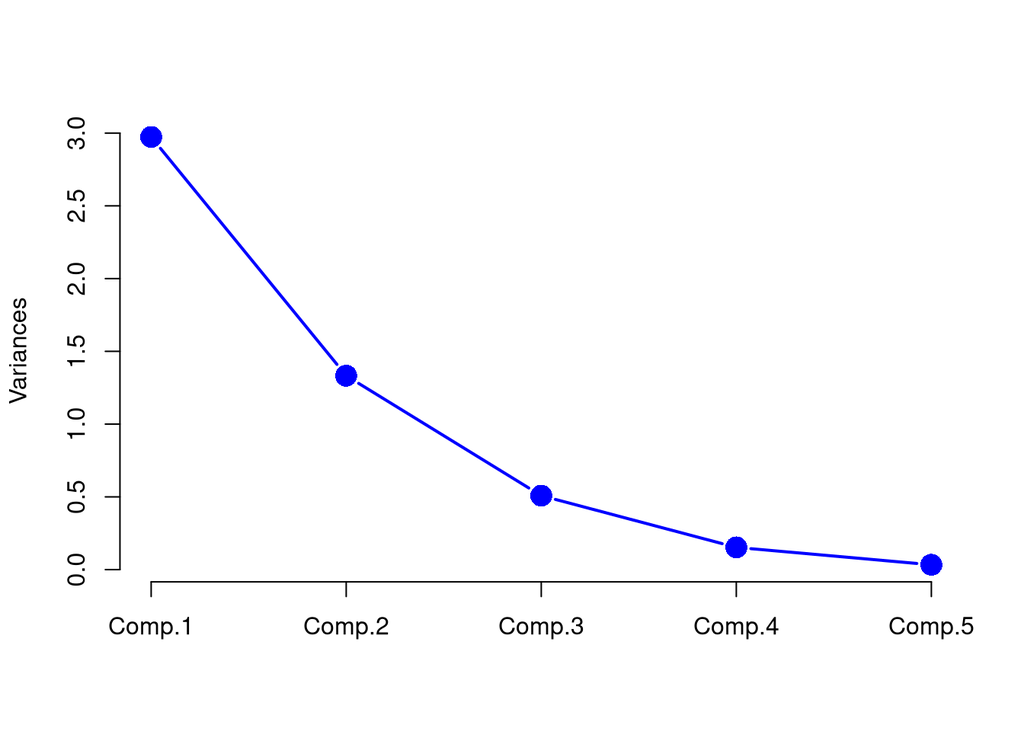

```r
screeplot(pcaUSA, col = 'blue', pch = 16, type = 'lines', cex = 2, lwd = 2, main = " ")
```

A módosított Kaiser szabály szerint csak a >=0.7 varianciájú komponenseket tartjuk meg, ebben az esetben az első kettőt.

## Faktoranalízis

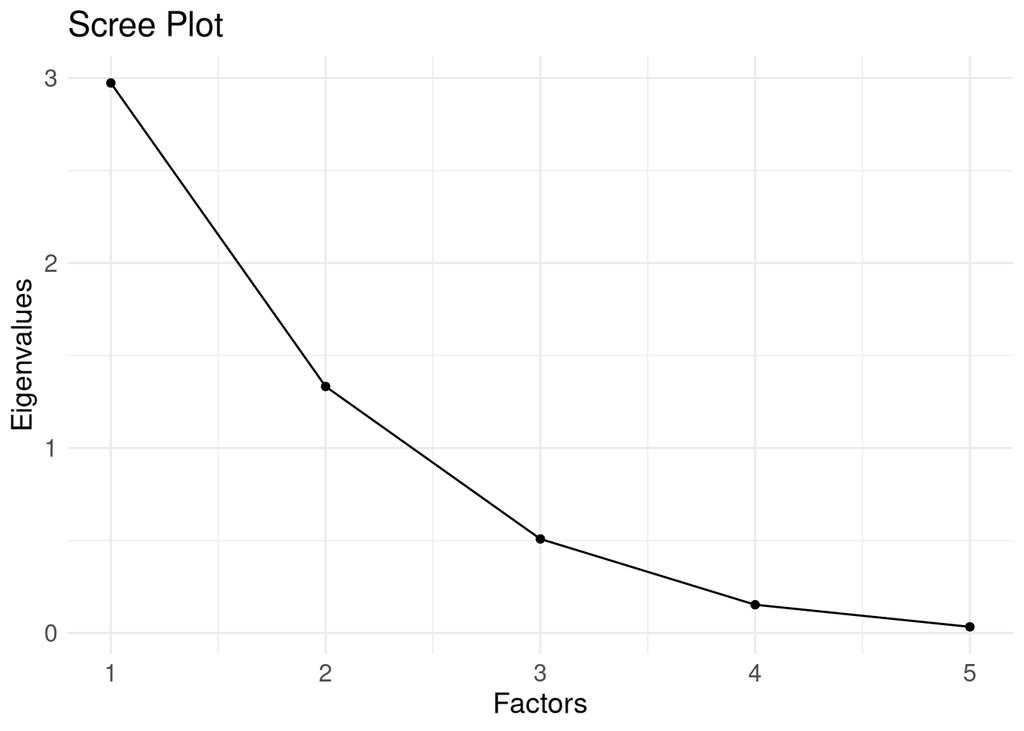

```r
eigen_values <- eigen(cor(usa_disorders))$values
scree_data <- data.frame(
  Factors = 1:length(eigen_values),
  Eigenvalues = eigen_values
)

ggplot(scree_data, aes(x = Factors, y = Eigenvalues)) +
  geom_point() +
  geom_line() +
  labs(title = "Scree Plot", x = "Factors", y = "Eigenvalues") +
  theme_minimal() +
  scale_x_continuous(breaks = 1:length(eigen_values)) +
  theme(axis.text.x = element_text(size = 12),
        axis.text.y = element_text(size = 12),
        title = element_text(size = 14))
```

Akkora faktorszámmal dolgozunk, amennyi sajátérték 1 fölött van az adathalmazon, ebben az esetben 2-vel

```r
fit <- factanal(usa_disorders, factors = 2, rotation="varimax")
print(fit)
```

```
##
## Call:
## factanal(x = usa_disorders, factors = 2, rotation = "varimax")
##
## Uniquenesses:
##        Schizophrenia Depressive_disorders    Anxiety_disorders
##                0.234                0.005                0.514
##    Bipolar_disorders     Eating_disorders
##                0.207                0.059
##
## Loadings:
##                      Factor1 Factor2
## Schizophrenia         0.875
## Depressive_disorders  0.656   0.752
## Anxiety_disorders     0.671   0.192
## Bipolar_disorders            -0.889
## Eating_disorders      0.970
##
##                Factor1 Factor2
## SS loadings      2.589   1.393
## Proportion Var   0.518   0.279
## Cumulative Var   0.518   0.796
##
## Test of the hypothesis that 2 factors are sufficient.
## The chi square statistic is 17.93 on 1 degree of freedom.
## The p-value is 2.29e-05
```

```r
usa_disorders$Code <- usa_illnesses$Code
china_disorders$Code <- china_illnesses$Code

#Check normality
normality <- array(NA, dim = c(5))
normality[1] <- shapiro.test(usa_disorders$Schizophrenia)$p.value > 0.5
normality[2] <- shapiro.test(usa_disorders$Depressive_disorders)$p.value > 0.5
normality[3] <- shapiro.test(usa_disorders$Anxiety_disorders)$p.value > 0.5
normality[4] <- shapiro.test(usa_disorders$Bipolar_disorders)$p.value > 0.5
normality[5] <- shapiro.test(usa_disorders$Eating_disorders)$p.value > 0.5

normality
```

```
## [1] FALSE FALSE FALSE FALSE FALSE
```

Az összes tulajdonság elbukott a shapiro-wilkins teszten, nem normális eloszlású az adat, így LDA, QDA kizárva. Logisztikus regressziót szintén nem használhatunk, mert nem elég nagy az adathalmaz, csupán 30-30 bejegyzés. Marad a klaszterezés.

## K-szomszéd klaszterezés

```r
library(caret)
library(class)
set.seed(123)

knn_illnesses <- rbind(usa_disorders, china_disorders)
knn_illnesses$Code <- factor(knn_illnesses$Code)
#Nem kéne hogy számítson, de a biztonság kedvéért megkeverem a sorokat
knn_illnesses <- knn_illnesses[sample(1:nrow(knn_illnesses)),]

#Klasszikus train/test split
train_index <- createDataPartition(knn_illnesses$Code, p = 0.7, list = FALSE)
train_data <- knn_illnesses[train_index,]
test_data <- knn_illnesses[-train_index,]

train_features <- train_data[, -ncol(train_data)]
train_labels <- train_data$Code
test_features <- test_data[, -ncol(test_data)]
test_labels <- test_data$Code

#Jellemzők standardizálása
train_features <- scale(train_features)
test_features <- scale(test_features)

k <- 2
knn_predictions <- knn(train = train_features, test = test_features, cl = train_labels, k = k)

# Pontosság kiszámítása
accuracy <- mean(knn_predictions == test_labels)
print(paste("Pontosság:", round(accuracy * 100, 2), "%"))
```

```
## [1] "Pontosság: 100 %"
```

```r
#Konfúziós mátrix

confusionMatrix(knn_predictions, as.factor(test_labels))
```

```
## Confusion Matrix and Statistics
##
##           Reference
## Prediction CHN USA
##        CHN   9   0
##        USA   0   9
##
##                Accuracy : 1
##                  95% CI : (0.8147, 1)
##     No Information Rate : 0.5
##     P-Value [Acc > NIR] : 3.815e-06
##
##                   Kappa : 1
##
##  Mcnemar's Test P-Value : NA
##
##             Sensitivity : 1.0
##             Specificity : 1.0
##          Pos Pred Value : 1.0
##          Neg Pred Value : 1.0
##              Prevalence : 0.5
##          Detection Rate : 0.5
##    Detection Prevalence : 0.5
##       Balanced Accuracy : 1.0
##
##        'Positive' Class : CHN
##
```

Az amerikai és kínai adatokat látszólag tökéletesen sikerült elkülöníteni. Azonban ez várható volt, mert a két ország között hatalmas különbségek vannak.

Nézzük meg, hogy mi történik, ha szomszédos országokat próbálunk ugyanúgy klaszterezni! Ezúttal európai országokat veszünk alapul, és a változatosság kedvéért k-közép klaszterezést használunk k-szomszéd helyett. Így viszont a tanítás is felügyeletlen lesz.

## K-közép klaszterezés

```r
library(cluster)
#Új mintavétel
france_illnesses <- illnesses[illnesses["Code"] == "FRA",]
germany_illnesses <- illnesses[illnesses["Code"] == "DEU",]
britain_illnesses <- illnesses[illnesses["Code"] == "GBR",]

kmeans_illnesses <- rbind(france_illnesses, germany_illnesses,britain_illnesses)
kmeans_illnesses <- kmeans_illnesses[c(2,4:8)]
#Itt sem kéne számítania tbh, de jól esik a lelki világomnak lol
kmeans_illnesses <- kmeans_illnesses[sample(1:nrow(kmeans_illnesses)),]
kmeans_illnesses$Code <- factor(kmeans_illnesses$Code)

#Kihagyjuk a Code oszlopot
kmeans_result <- kmeans(kmeans_illnesses[,-1], centers=3, nstart=25)

kmeans_result
```

```
## K-means clustering with 3 clusters of sizes 30, 30, 30
##
## Cluster means:
##   Schizophrenia Depressive_disorders Anxiety_disorders Bipolar_disorders
## 1     0.2601667             3.337654          6.117967         0.7498523
## 2     0.2558147             4.172420          4.379163         1.0918969
## 3     0.2686167             4.070869          6.333421         0.9034444
##   Eating_disorders
## 1        0.4026529
## 2        0.3893076
## 3        0.4411544
##
## Clustering vector:
## 2195 6049 2094 6057 2077 6059 2093 2096 2192 6056 2097 2202 2075 6040 2086 6058
##    1    2    3    2    3    2    3    3    1    2    3    1    3    2    3    2
## 6052 2091 2215 2196 2199 2214 2079 2208 2216 6047 2074 2071 2200 2100 6031 2212
##    2    3    1    1    1    1    3    1    1    2    3    3    1    3    2    1
## 2095 6046 6045 6039 2081 6037 2090 6032 2073 2099 6041 2204 2092 6055 2219 6042
##    3    2    2    2    3    2    3    2    3    3    2    1    3    2    1    2
## 2078 6043 2072 2083 2076 2205 6044 2084 2217 6054 2209 6033 2197 2220 2080 2218
##    3    2    3    3    3    1    2    3    1    2    1    2    1    1    3    1
## 2213 2088 2201 6038 6051 2206 2098 2203 2191 2207 6048 2198 6035 2089 6060 2193
##    1    3    1    2    2    1    3    1    1    1    2    1    2    3    2    1
## 6034 6036 6050 2082 2211 2087 6053 2194 2210 2085
##    2    2    2    3    1    3    2    1    1    3
##
## Within cluster sum of squares by cluster:
## [1] 0.9060972 0.9627702 1.5387162
##  (between_SS / total_SS =  96.1 %)
##
## Available components:
##
## [1] "cluster"      "centers"      "totss"        "withinss"     "tot.withinss"
## [6] "betweenss"    "size"         "iter"         "ifault"
```

```r
confusion_matrix <- table(True_Label = kmeans_illnesses$Code, Cluster = kmeans_result$cluster)
print(confusion_matrix)
```

```
##           Cluster
## True_Label  1  2  3
##        DEU 30  0  0
##        FRA  0  0 30
##        GBR  0 30  0
```

Úgy tűnik a szomszédság ellenére egyértelműen elválaszthatóak az értékek. (Ebből kiindulva valószínűleg nem valósak az adatok). Itt nem csináltam tanuló/tesztelő halmaz felbontást, mert felügyeletlen tanulásnál az a feltételezés hogy nincs mihez hasonlítani a jóságot, így a `kmeans` függvénynek sincs `test` paramétere.